# Udacity DAND Project: ExploreAndSummarizeData

Jubin Soni

August 27, 2017

## Loading all the packages

```r
library(ggplot2)
library(grid)
library(gridExtra)
library(dplyr)
library(tidyr)
```

## Loading the Dataset

```r
wine <- read.csv("wineQualityWhites.csv", row.names = NULL)
```

## Initial Data Exploration

```r
names(wine)
```

```
##  [1] "X"                    "fixed.acidity"        "volatile.acidity"
##  [4] "citric.acid"          "residual.sugar"       "chlorides"
##  [7] "free.sulfur.dioxide"  "total.sulfur.dioxide" "density"
## [10] "pH"                   "sulphates"            "alcohol"
## [13] "quality"
```

```r
str(wine)
```

```
## 'data.frame':    4898 obs. of  13 variables:
##  $ X                   : int  1 2 3 4 5 6 7 8 9 10 ...
##  $ fixed.acidity       : num  7 6.3 8.1 7.2 7.2 8.1 6.2 7 6.3 8.1 ...
##  $ volatile.acidity    : num  0.27 0.3 0.28 0.23 0.23 0.28 0.32 0.27 0.3 0.22 ...
##  $ citric.acid         : num  0.36 0.34 0.4 0.32 0.32 0.4 0.16 0.36 0.34 0.43 ...
##  $ residual.sugar      : num  20.7 1.6 6.9 8.5 8.5 6.9 7 20.7 1.6 1.5 ...
##  $ chlorides           : num  0.045 0.049 0.05 0.058 0.058 0.05 0.045 0.045 0.049 0.044 ...
##  $ free.sulfur.dioxide : num  45 14 30 47 47 30 30 45 14 28 ...
##  $ total.sulfur.dioxide: num  170 132 97 186 186 97 136 170 132 129 ...
##  $ density             : num  1.001 0.994 0.995 0.996 0.996 ...
##  $ pH                  : num  3 3.3 3.26 3.19 3.19 3.26 3.18 3 3.3 3.22 ...
##  $ sulphates           : num  0.45 0.49 0.44 0.4 0.4 0.44 0.47 0.45 0.49 0.45 ...
##  $ alcohol             : num  8.8 9.5 10.1 9.9 9.9 10.1 9.6 8.8 9.5 11 ...
##  $ quality             : int  6 6 6 6 6 6 6 6 6 6 ...
```

```r
summary(wine)
```

```
##        X        fixed.acidity    volatile.acidity  citric.acid
##  Min.   :   1   Min.   : 3.800   Min.   :0.0800   Min.   :0.0000
##  1st Qu.:1225   1st Qu.: 6.300   1st Qu.:0.2100   1st Qu.:0.2700
##  Median :2450   Median : 6.800   Median :0.2600   Median :0.3200
##  Mean   :2450   Mean   : 6.855   Mean   :0.2782   Mean   :0.3342
##  3rd Qu.:3674   3rd Qu.: 7.300   3rd Qu.:0.3200   3rd Qu.:0.3900
##  Max.   :4898   Max.   :14.200   Max.   :1.1000   Max.   :1.6600
##  residual.sugar     chlorides       free.sulfur.dioxide
##  Min.   : 0.600   Min.   :0.00900   Min.   :  2.00
##  1st Qu.: 1.700   1st Qu.:0.03600   1st Qu.: 23.00
##  Median : 5.200   Median :0.04300   Median : 34.00
##  Mean   : 6.391   Mean   :0.04577   Mean   : 35.31
##  3rd Qu.: 9.900   3rd Qu.:0.05000   3rd Qu.: 46.00
##  Max.   :65.800   Max.   :0.34600   Max.   :289.00
##  total.sulfur.dioxide    density             pH          sulphates
##  Min.   :  9.0        Min.   :0.9871   Min.   :2.720   Min.   :0.2200
##  1st Qu.:108.0        1st Qu.:0.9917   1st Qu.:3.090   1st Qu.:0.4100
##  Median :134.0        Median :0.9937   Median :3.180   Median :0.4700
##  Mean   :138.4        Mean   :0.9940   Mean   :3.188   Mean   :0.4898
##  3rd Qu.:167.0        3rd Qu.:0.9961   3rd Qu.:3.280   3rd Qu.:0.5500
##  Max.   :440.0        Max.   :1.0390   Max.   :3.820   Max.   :1.0800
##     alcohol         quality
##  Min.   : 8.00   Min.   :3.000
##  1st Qu.: 9.50   1st Qu.:5.000
##  Median :10.40   Median :6.000
##  Mean   :10.51   Mean   :5.878
##  3rd Qu.:11.40   3rd Qu.:6.000
##  Max.   :14.20   Max.   :9.000
```

### Structure of Dataset

The dataset on white wines has 4898 observations of 13 variables. The main feature of interest is quality and alcohol content.

## Univariate Analysis

### Plotting quality of wine

We see that the quality is close to a normal distribution, the graph is which is not fully symmetric because the quality 5 is higher than its corresponding value. However looking at the quality of 6 being highest we can say that the quality is above average.

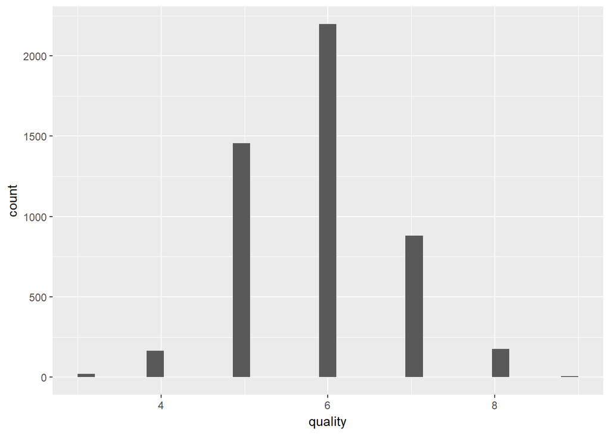

```r
library(ggplot2)
ggplot(aes(x = quality), data = wine) +
  geom_histogram()
```

### Histogram of fixed.acidity value of wine

The histogram of acidity of potential shows normal distribution.

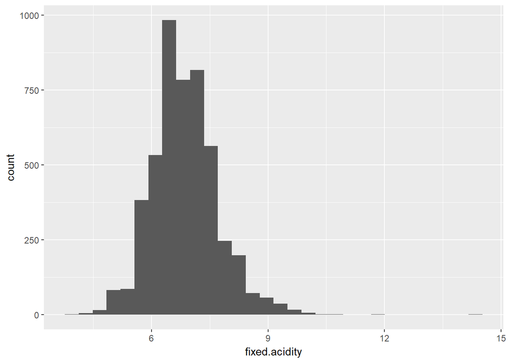

```r
ggplot(aes(x = fixed.acidity), data = wine) +
  geom_histogram()
```

### Histogram of residual sugar

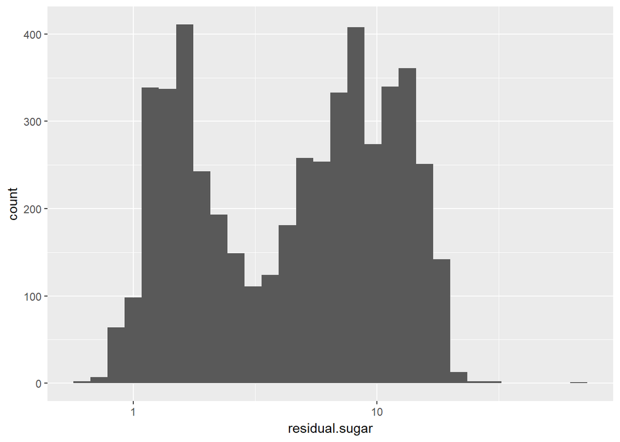

```r
ggplot(aes(x = residual.sugar), data = wine) +
  geom_histogram() +
  scale_x_log10()
```

### Histogram of Sulpur dioxide

The histogram of Sulfur Dioxide shows normal distribution in the White wine.

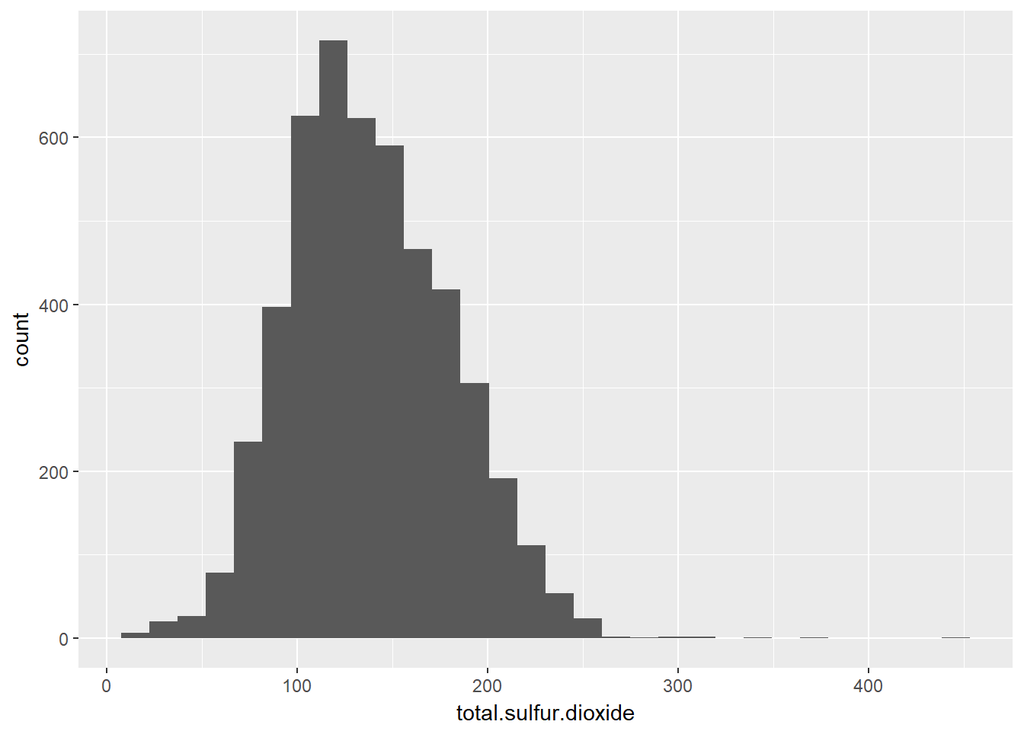

```r
ggplot(aes(x = total.sulfur.dioxide), data = wine) +
  geom_histogram()
```

### Plotting pH of wine

The pH is very narrow for White Wine between 2.7 to 3.8, so it seems like these values are within the acidity range and no alkaline (which is above 7)

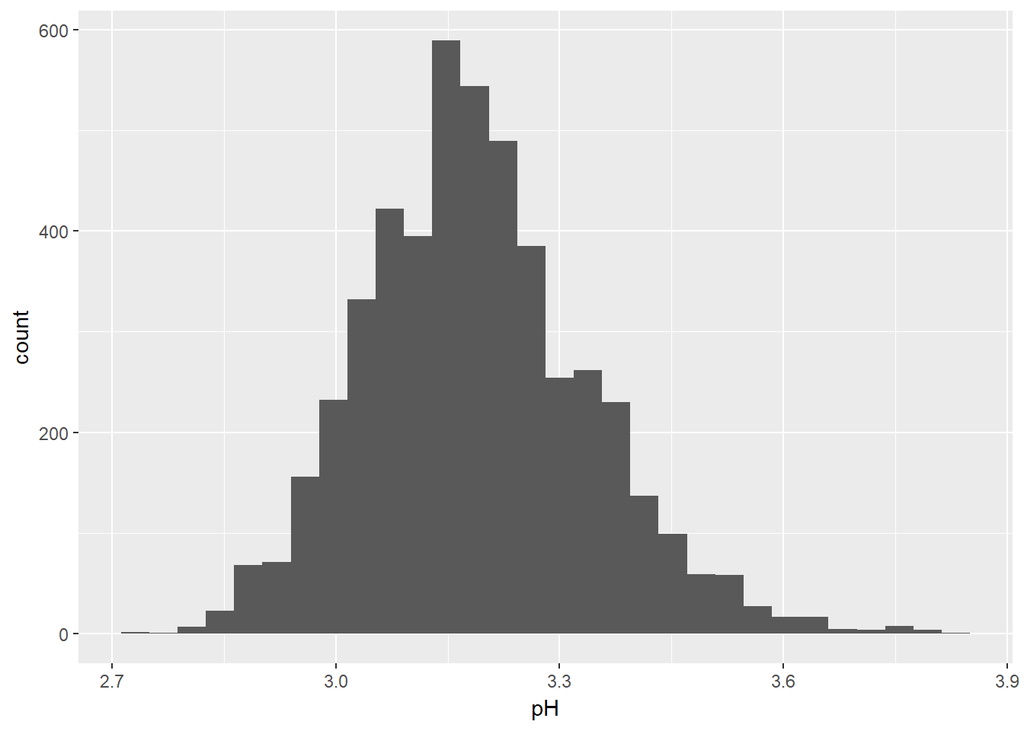

```r
ggplot(aes(x = pH), data = wine) +
  geom_histogram()
```

### Checking Wine Density

The distribution below shows that density is within 0.9 to 1.0 range.

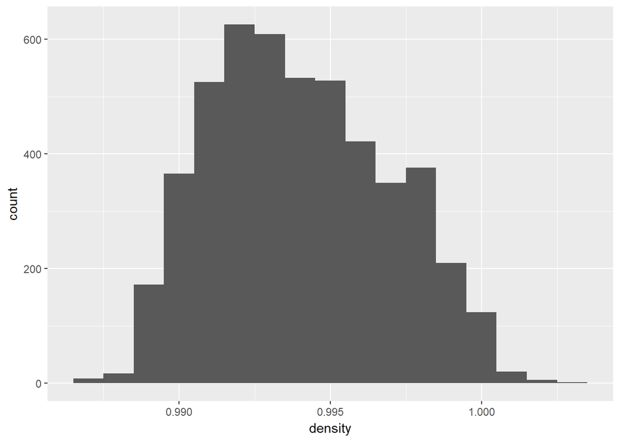

```r
ggplot(aes(x = density), data = subset(wine, density<1.01)) +
  geom_histogram(binwidth = 0.001)
```

### Univariate Analysis Questions and Findings

#### What other features in the dataset do you think will help support your investigation into your feature(s) of interest?

I think further investigation weather pH could be classified into categorial (acid, base, neutral) could potentially be of interest. Also the relationship between fixed.acidity, volatile.acidity, and citric.acid (in particular this one due to the large number of 0s) could be interesting to further investigate in order to understand if the values are properly reported. This would require to understand the theoretical relationship between these variables.

#### Did you create any new variables from existing variables in the dataset?

I only created the variable (ordered factor) rating to classify wine as good, bad or average. The information that the other variables store there does not seem to be any other variable that would fit well a sub-classification into categorical variables, perhaps with the exception of residual pH (neutral, base, acid).

#### Did you perform any operations on the data to tidy, adjust, or change the form of the data? If so, why did you do this?

I’ve not found the need to tidy, adjust, or change the form of the data.

### Bivariate Analysis

Let us check how is the distribution of quality and alcohol content in wine. To do this creating a new variable alcohol.bucket.

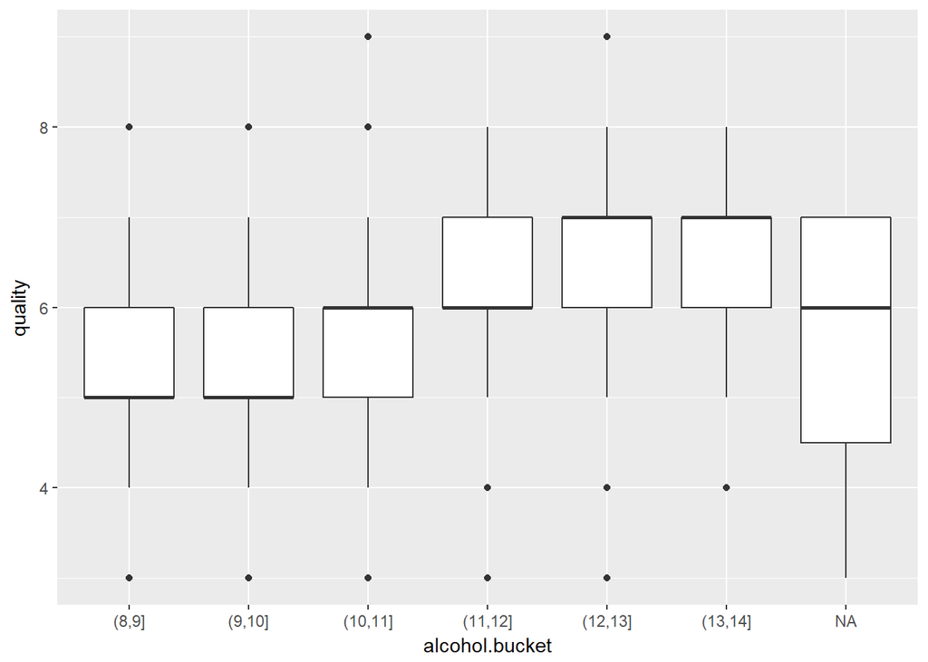

```r
wine$alcohol.bucket <- cut(wine$alcohol, c(8,9,10,11,12,13,14))
qplot(x = alcohol.bucket, y= quality, data = wine, geom = 'boxplot')
```

The graphs shows us that alcohol and wine quality have clear correlation.